# Experiments with data

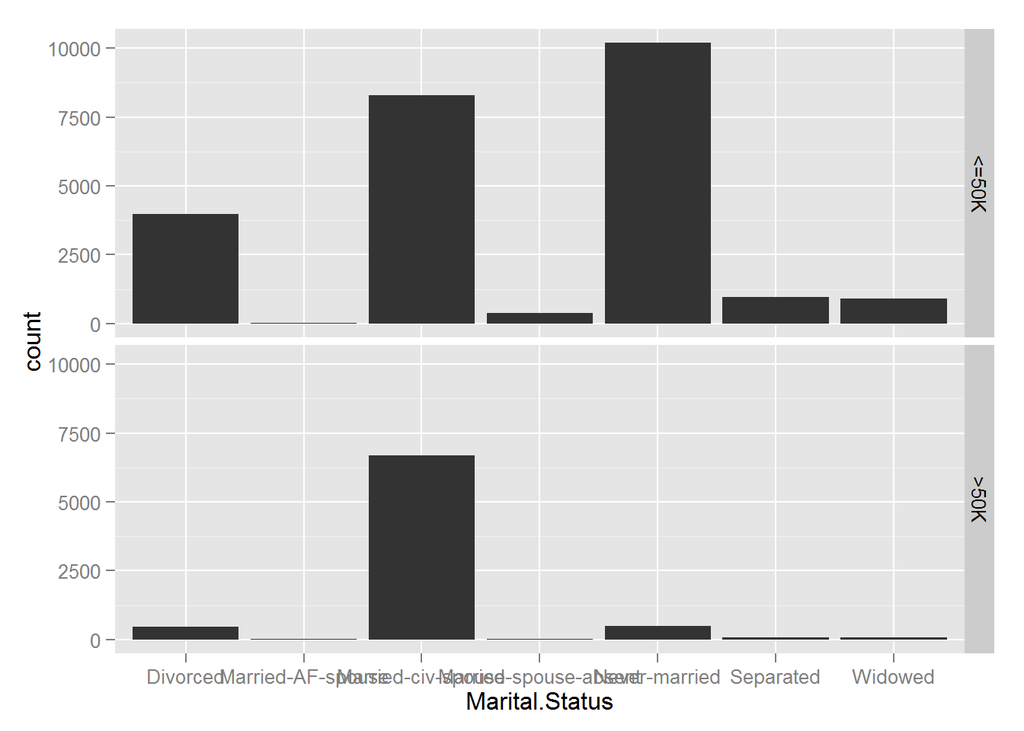

```r
#also makes a difference

#marital status
print(ggplot(data=train,aes(x=Marital.Status))+geom_bar()+facet_grid(Income.Group~.))
```

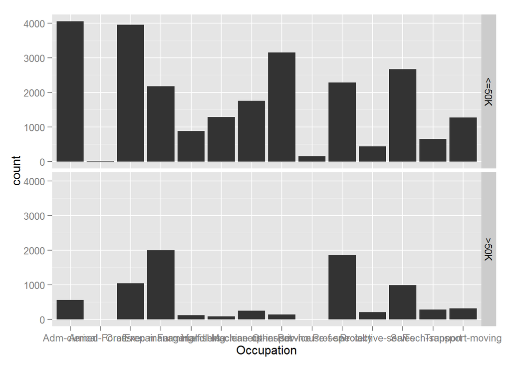

```r
#a big difference

#occupation
print(ggplot(data=train,aes(x=Occupation))+geom_bar()+facet_grid(Income.Group~.))
```

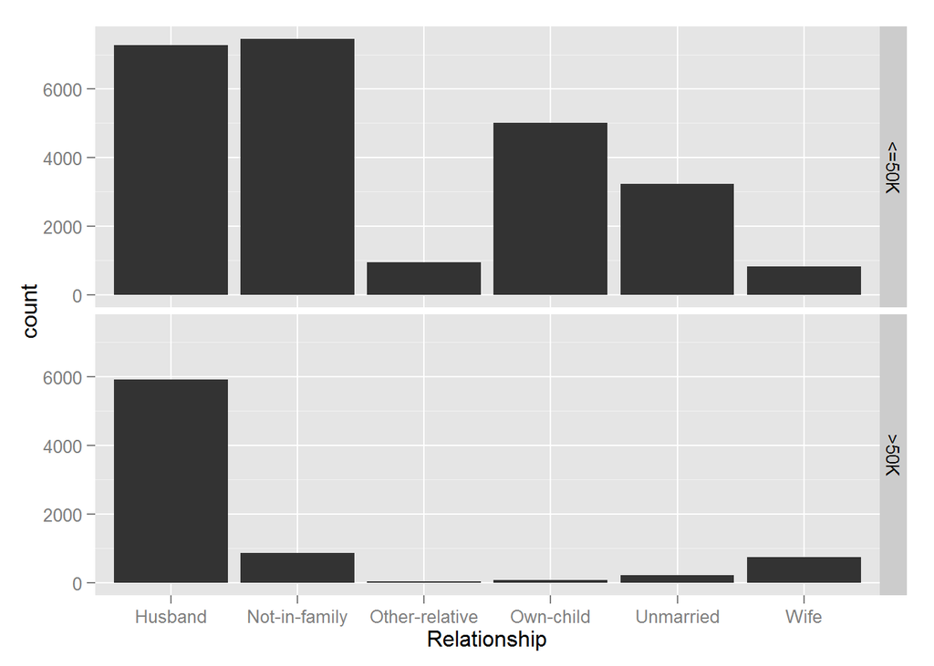

```r
#also makes a difference

#relationship
print(ggplot(data=train,aes(x=Relationship))+geom_bar()+facet_grid(Income.Group~.))
```

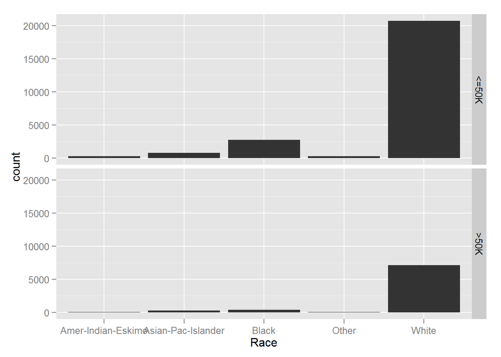

```r
#this too

#race
print(ggplot(data=train,aes(x=Race))+geom_bar()+facet_grid(Income.Group~.))
```

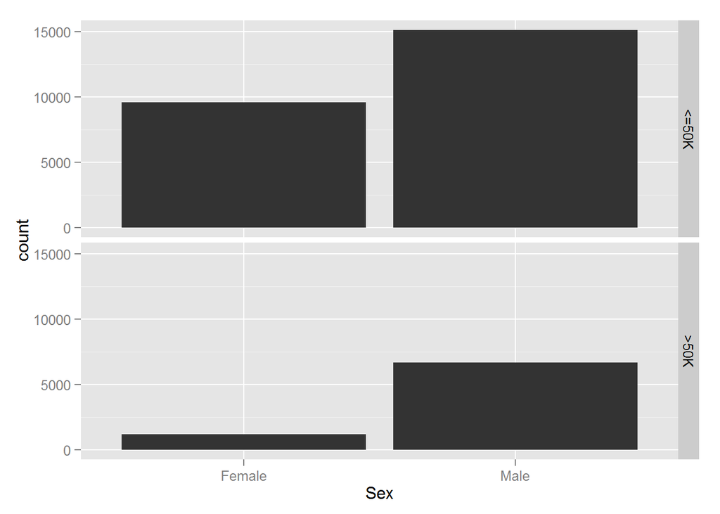

```r
#and this

#sex
print(ggplot(data=train,aes(x=Sex))+geom_bar()+facet_grid(Income.Group~.))
```

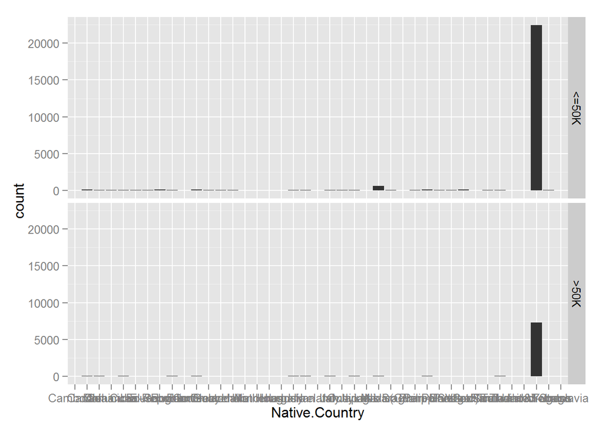

```r
#definitely

#native country
print(ggplot(data=train,aes(x=Native.Country))+geom_bar()+facet_grid(Income.Group~.))
```

```r
#there are too many levels.
summary(country$Income.Group[,2])
```

```
##    Min. 1st Qu.  Median    Mean 3rd Qu.    Max.
## 0.00000 0.08491 0.20000 0.20240 0.32120 0.41860
```

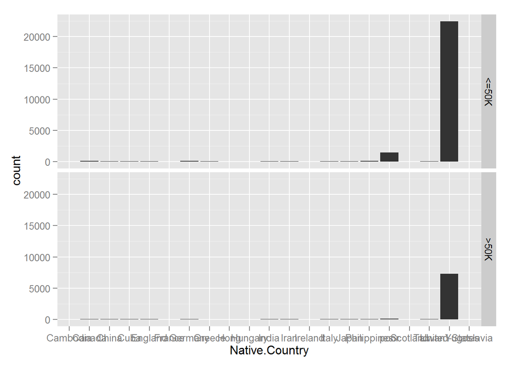

```r
#this shows the statistics of the proportion of >50 by country
#group countries with less than median as poor
poor<-country$Native.Country[country$Income.Group[,2]<=0.2]
mydata$Native.Country<-as.character(mydata$Native.Country)
mydata$Native.Country[mydata$Native.Country%in% poor]<-"poor"
mydata$Native.Country<-as.factor(mydata$Native.Country)

#reseparate into train and test sets
train<-cbind(mydata[1:32561,],Income.Group=train$Income.Group)
test<-mydata[32562:48842,]

print(ggplot(data=train,aes(x=Native.Country))+geom_bar()+facet_grid(Income.Group~.))
```

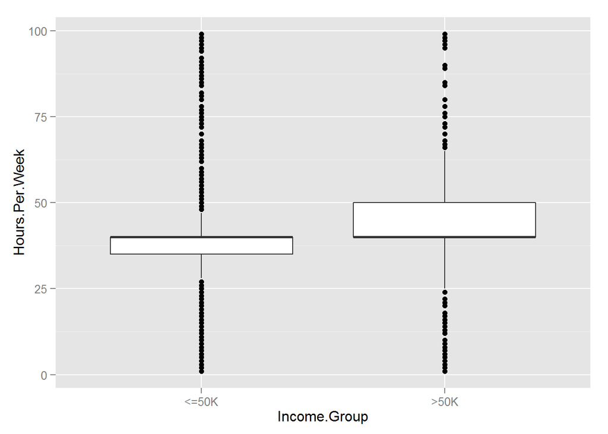

```r
#hours per week
print(ggplot(data=train,aes(x=Income.Group,y=Hours.Per.Week))+geom_boxplot())
```

```r
#75% of the <50 work less hours than 25% of >50.Many outliers
```

## Prepare the data for modelling

It is mecessary to create a fictive Income group for test set, so that the mlr package can be used.

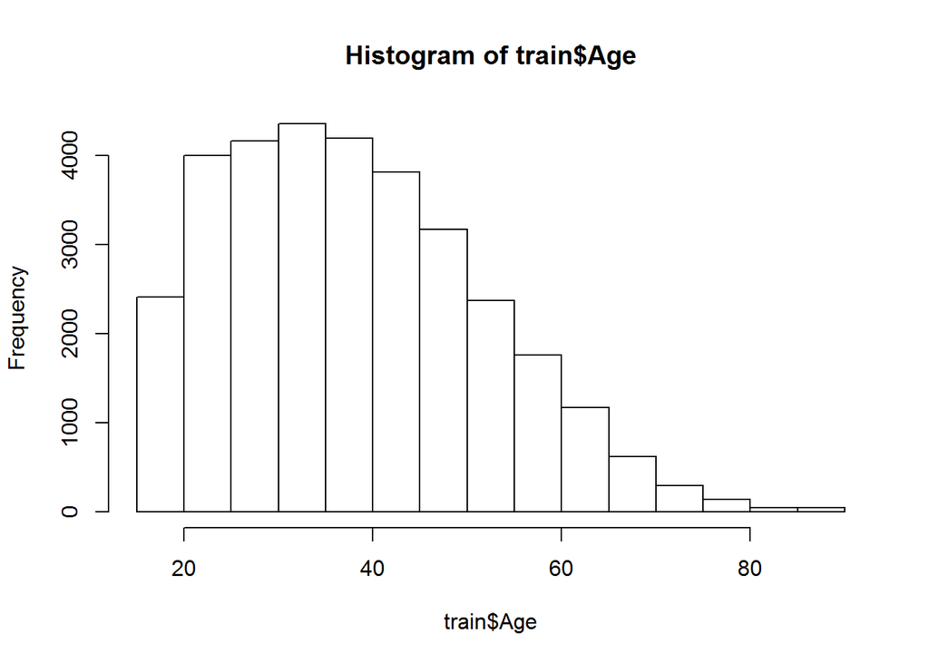

```r
test$Income.Group<-as.factor(sample(levels(train$Income.Group),dim(test)[1],replace=TRUE,c(0.5,0.5)))

#remove ID variable. This should not be included in the anaylsis.
train<-train[,2:12]
test<-test[,2:12]
#model
trainTask <- makeClassifTask(data = train,target = "Income.Group")
testTask <- makeClassifTask(data = test, target = "Income.Group")

#both numeric variables are skewed, they need to be normalized before training
hist(train$Age)
```

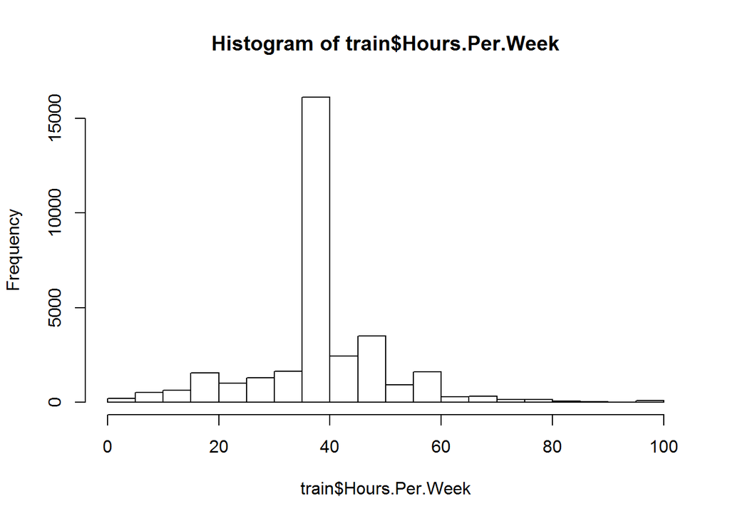

```r
hist(train$Hours.Per.Week)
```

```r
trainTask <- normalizeFeatures(trainTask,method = "standardize")
testTask <- normalizeFeatures(testTask,method = "standardize")
```

## Tune and train models, and predict

1. rpart

```r
#make tree learner
makeatree <- makeLearner("classif.rpart", predict.type = "response")

#set 5 fold cross validation
set_cv <- makeResampleDesc("CV",iters = 5L)

#Search for hyperparameters
gs <- makeParamSet(
        makeIntegerParam("minsplit",lower = 10, upper = 50),
        makeIntegerParam("minbucket", lower = 5, upper = 50),
        makeNumericParam("cp", lower = 0.001, upper = 0.2)
)
gscontrol <- makeTuneControlGrid()

#hypertune the parameters
stune <- tuneParams(learner = makeatree, resampling = set_cv,
                    task = trainTask, par.set = gs, control = gscontrol, measures = acc)
```

```r
stune
```

```
## Tune result:
## Op. pars: minsplit=37; minbucket=15; cp=0.001
## acc.test.mean=0.84
```

```r
#using hyperparameters for modeling,train the model using caret package
treefit<-train(data=train,Income.Group~.,"rpart",minsplit=37,minbucket=15,cp=0.001)
```

```r
#make predictions
tpmodel <- predict(treefit, test)

# #create a submission file
# submit <- data.frame(ID = mydata$ID[32562:48842], Income.Group = tpmodel)
# write.csv(submit, "submission1.csv",row.names = F)
```

This model gives about 0.82 accuracy on the public leaderboard. Perhaps this can be improved using random forest.  
2. rf

```r
#create a learner
rf <- makeLearner("classif.randomForest", predict.type = "response"
                  , par.vals = list(ntree = 200, mtry = 3))
rf$par.vals <- list(importance = TRUE)

#set tunable parameters
#grid search to find hyperparameters
rf_param <- makeParamSet(
        makeIntegerParam("ntree",lower = 50, upper = 500),
        makeIntegerParam("mtry", lower = 3, upper = 10),
        makeIntegerParam("nodesize", lower = 10, upper = 50)
)

#random search for 50 iterations, it will take far too long to cover all the grid
rancontrol <- makeTuneControlRandom(maxit = 50L)

#set 5 fold cross validation
set_cv <- makeResampleDesc("CV",iters = 5L)

#hypertuning
rf_tune <- tuneParams(learner = rf, resampling = set_cv, task = trainTask, par.set = rf_param, control = rancontrol, measures = acc)
```

```r
#cv accuracy
rf_tune$y
```

```
## acc.test.mean
##     0.8438929
```

```r
#best parameters
rf_tune$x
```

```
## $ntree
## [1] 407
##
## $mtry
## [1] 3
##
## $nodesize
## [1] 44
```

Trying to use mlr to train the model after hypertuning resulted in errors.(EDIT:I later realised that there were conflictions between caret train and mlr train, and caret must be unloaded to prevent this error.) I used caret train instead. This did not allow me to override its search for optimal mtry but I fixed the other tuning parameters to the above values.

```r
#train the model
rffit<-train(data=train,Income.Group~.,"rf",ntree=407,nodesize=44)
```

```r
#make predictions
rfmodel <- predict(rffit, test)

# #create a submission file
# submit <- data.frame(ID = mydata$ID[32562:48842], Income.Group = rfmodel)
# write.csv(submit, "submission2.csv",row.names = F)
```

Interestingly, the optimal mtry turned out to be 2, which I hadn’t included in the hypertuning search.  
The accuracy on the public leaderboard increased to 0.84.

## Looking for further improvement

```r
library(caret)
varImp(rffit)
```

```
## rf variable importance
##
##   only 20 most important variables shown (out of 72)
##
##                                  Overall
## Marital.StatusMarried-civ-spouse 100.000
## Age                               41.357
## Hours.Per.Week                    28.873
## OccupationProf-specialty          21.030
## Marital.StatusNever-married       20.687
## OccupationExec-managerial         18.458
## EducationBachelors                17.291
## EducationMasters                   8.576
## SexMale                            5.446
## EducationProf-school               4.997
## EducationHS-grad                   4.446
## WorkclassSelf-emp-not-inc          4.379
## EducationSome-college              4.014
## EducationDoctorate                 3.961
## RelationshipWife                   3.286
## OccupationSales                    3.261
## OccupationTech-support             3.143
## OccupationOther-service            2.725
## RelationshipNot-in-family          2.494
## Native.Countrypoor                 2.286
```

```r
varImp(treefit)
```

```
## rpart variable importance
##
##   only 20 most important variables shown (out of 78)
##
##                                    Overall
## Marital.StatusMarried-civ-spouse   100.000
## Age                                 64.699
## Marital.StatusNever-married         51.278
## Hours.Per.Week                      41.753
## EducationBachelors                  37.147
## OccupationExec-managerial           32.574
## RelationshipOwn-child               26.410
## OccupationProf-specialty            14.447
## EducationHS-grad                    11.153
## EducationMasters                     6.726
## OccupationSales                      4.712
## Native.Countrypoor                   2.657
## `OccupationArmed-Forces`             0.000
## Native.CountryGreece                 0.000
## `Marital.StatusMarried-civ-spouse`   0.000
## `OccupationProtective-serv`          0.000
## `EducationHS-grad`                   0.000
## Marital.StatusSeparated              0.000
## Native.CountryHong                   0.000
## `RelationshipOther-relative`         0.000
```

I now try to improve accuracy by combining levels of factors that are not important.

```r
library(car)
train$Occupation<-recode(train$Occupation,"c('Adm-clerical','Armed-Forces','Craft-repair','Farming-fishing', 'Handlers-cleaners', 'Machine-op-inspct', 'Protective-serv' , 'Priv-house-serv','Transport-moving' ) = 'other'")
test$Occupation<- recode(test$Occupation,"c('Adm-clerical','Armed-Forces','Craft-repair','Farming-fishing', 'Handlers-cleaners', 'Machine-op-inspct', 'Protective-serv' , 'Priv-house-serv','Transport-moving' )='other'")
train$Education<- recode(train$Education,"c('10th','11th','12th','1st-4th','5th-6th','7th-8th', '9th','Assoc-acdm','Assoc-voc','Preschool' )='low'")
test$Education<- recode(test$Education,"c('10th','11th','12th','1st-4th','5th-6th','7th-8th', '9th','Assoc-acdm','Assoc-voc','Preschool' )='low'")
train$Marital.Status<-recode(train$Marital.Status,"c('Divorced','Married-AF-spouse','Married-spouse-absent','Separated','Widowed')='other'")
test$Marital.Status<-recode(test$Marital.Status,"c('Divorced','Married-AF-spouse','Married-spouse-absent','Separated','Widowed')='other'")
train$Workclass<-recode(train$Workclass,"c('Federal-gov','Local-gov','State-gov')='gov'")
test$Workclass<-recode(test$Workclass,"c('Federal-gov','Local-gov','State-gov')='gov'")
train$Native.Country <-recode(train$Native.Country,"c('Cambodia','Canada', 'China','Cuba','England','France','Germany','Greece','Hong','Hungary','India', 'Iran','Ireland','Italy','Japan','Philippines','Scotland','Taiwan','Yugoslavia'   )='other'")
test$Native.Country <-recode(test$Native.Country,"c('Cambodia','Canada', 'China','Cuba','England','France','Germany','Greece','Hong','Hungary','India', 'Iran','Ireland','Italy','Japan','Philippines','Scotland','Taiwan','Yugoslavia'   )='other'")
```

Make new rf:

```r
#make task
trainTask <- makeClassifTask(data = train,target = "Income.Group")
testTask <- makeClassifTask(data = test, target = "Income.Group")

#normalizae

trainTask <- normalizeFeatures(trainTask,method = "standardize")
testTask <- normalizeFeatures(testTask,method = "standardize")
#create a learner
rf2 <- makeLearner("classif.randomForest", predict.type = "response"
                  , par.vals = list(ntree = 200, mtry = 3))
rf$par.vals <- list(importance = TRUE)

#set tunable parameters
#grid search to find hyperparameters
rf_param <- makeParamSet(
        makeIntegerParam("ntree",lower = 50, upper = 500),
        makeIntegerParam("mtry", lower = 2, upper = 4),
        makeIntegerParam("nodesize", lower = 10, upper = 50)
)

#random search for 50 iterations, it will take far too long to cover all the grid
rancontrol <- makeTuneControlRandom(maxit = 50L)

#set 5 fold cross validation
set_cv <- makeResampleDesc("CV",iters = 5L)

#hypertuning
rf_tune2 <- tuneParams(learner = rf2, resampling = set_cv, task = trainTask, par.set = rf_param, control = rancontrol, measures = acc)

#using hyperparameters for modeling
rf.tree <- setHyperPars(rf2, par.vals = rf_tune2$x)
#train a model
unloadNamespace("caret")
rforest <- train(learner=rf.tree, task=trainTask)

#make predictions
rfmodel2 <- predict(rforest, testTask)

# #create a submission file
# submit <- data.frame(ID = mydata$ID[32562:48842], Income.Group = rfmodel2$data$response)
#  write.csv(submit, "submission3.csv",row.names = F)
```

This didn’t lead to an improvement, of course, but achieved the same accuracy a little more efficiently.

Now I’ll try xgboost using the mlr package.

```r
#create a learner
xgb <- makeLearner("classif.xgboost", predict.type = "response"
                  , par.vals = list(eta=0.1,gamma=0,max_depth=6,min_child_weight=1,subsample=0.8,colsample_bytree=0.8,nthread=2,nrounds=1))
xgb$par.vals <- list(importance = TRUE)

#set tunable parameters
#grid search to find hyperparameters
xgb_param <- makeParamSet(
        makeNumericParam("eta",lower = 0.05, upper = 0.3),
        makeNumericParam("gamma", lower = 0, upper = 3),
        makeNumericParam("subsample", lower = 0.5, upper = 1),
        makeNumericParam("colsample_bytree", lower = 0.5, upper = 1),
        makeDiscreteParam("max_depth" ,values=3:10),
        makeDiscreteParam("min_child_weight",values=1:8),
        makeDiscreteParam("nrounds",values=1:100)
)

#let's do random search for 100 iterations
rancontrol <- makeTuneControlRandom(maxit = 100L)

#set 5 fold cross validation
set_cv <- makeResampleDesc("CV",iters = 5L)

#hypertuning
xgb_tune <- tuneParams(learner = xgb, resampling = set_cv, task = trainTask, par.set = xgb_param, control = rancontrol, measures = acc)
```

```r
#cv accuracy
xgb_tune$y
```

```
## acc.test.mean
##     0.8393168
```

```r
#best parameters
xgb_tune$x
```

```
## $eta
## [1] 0.1482234
##
## $gamma
## [1] 1.766518
##
## $subsample
## [1] 0.735649
##
## $colsample_bytree
## [1] 0.5425878
##
## $max_depth
## [1] 8
##
## $min_child_weight
## [1] 4
##
## $nrounds
## [1] 48
```

```r
#using hyperparameters for modeling
xgb.tuned <- setHyperPars(xgb, par.vals = xgb_tune$x)
```

```r
#train a model
xgb.fit <- train(xgb.tuned, trainTask)
```

```r
#make predictions
xgbmodel <- predict(xgb.fit, testTask)

#submission file
#  submit <- data.frame(ID = mydata$ID[32562:48842], Income.Group = xgbmodel$data$response)
# write.csv(submit, "submission4.csv",row.names = F)
```